# Practical Solutions

## TIDY GRAPH - WORKFLOW

**STEP 0** Download packages. Download and explore data.

```r
#install.packages("tidygraph")
#install.packages("ggraph")
#devtools::install_github('thomasp85/ggraph') #only for newest insights, and not for today;)

library(tidygraph)
library(tidyverse)
library(ggraph)
library(ggplot2)
```

```r
nodes <- read.csv("https://kateto.net/workshops/data/Dataset1-Media-Example-NODES.csv", header=T, as.is=T)
edges <- read.csv("https://kateto.net/workshops/data/Dataset1-Media-Example-EDGES.csv", header=T, as.is=T)

head(nodes)
```

```
##    id               media media.type type.label audience.size
## 1 s01            NY Times          1  Newspaper            20
## 2 s02     Washington Post          1  Newspaper            25
## 3 s03 Wall Street Journal          1  Newspaper            30
## 4 s04           USA Today          1  Newspaper            32
## 5 s05            LA Times          1  Newspaper            20
## 6 s06       New York Post          1  Newspaper            50
```

```r
head(edges)
```

```
##   from  to      type weight
## 1  s01 s02 hyperlink     22
## 2  s01 s03 hyperlink     22
## 3  s01 s04 hyperlink     21
## 4  s01 s15   mention     20
## 5  s02 s01 hyperlink     23
## 6  s02 s03 hyperlink     21
```

SOURCE of data: https://github.com/kateto/R-igraph-Network-Workshop-NetSciX/blob/master/Dataset1-Media-Example-NODES.csv and https://www.rpubs.com/Steven_Surya/tidygraph-ggraph/

**STEP 1.** Create a tbl_graph object using the above data. Print and plot it.

```r
news_media<-tbl_graph(nodes,edges)
news_media
```

```
## # A tbl_graph: 17 nodes and 49 edges
## #
## # A directed multigraph with 1 component
## #
## # Node Data: 17 × 5 (active)
##   id    media               media.type type.label audience.size
##   <chr> <chr>                    <int> <chr>              <int>
## 1 s01   NY Times                     1 Newspaper             20
## 2 s02   Washington Post              1 Newspaper             25
## 3 s03   Wall Street Journal          1 Newspaper             30
## 4 s04   USA Today                    1 Newspaper             32
## 5 s05   LA Times                     1 Newspaper             20
## 6 s06   New York Post                1 Newspaper             50
## # … with 11 more rows
## #
## # Edge Data: 49 × 4
##    from    to type      weight
##   <int> <int> <chr>      <int>
## 1     1     2 hyperlink     22
## 2     1     3 hyperlink     22
## 3     1     4 hyperlink     21
## # … with 46 more rows
```

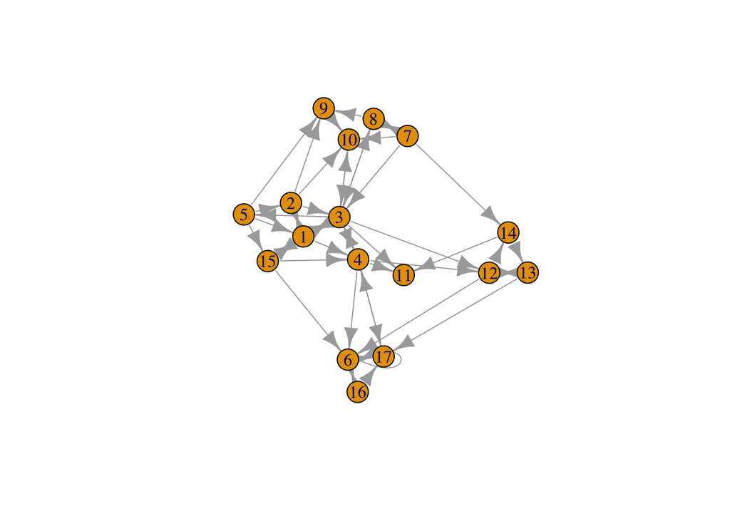

```r
plot(news_media)
```

**EXAMPLE 1.** Media outlets are linked by either “hyperlink” or “mention”. Out of your combined data filter these media outlets that are link by “hyperlink” only and by “mention”s. Assign them to new data sets. Lastly, plot them.

HINT: By using **activate()** we can specify whether we would like to work on the edges or nodes.

```r
media_hyper<-news_media %>% activate(edges) %>% filter(type=="hyperlink")
media_hyper
```

```
## # A tbl_graph: 17 nodes and 29 edges
## #
## # A directed multigraph with 2 components
## #
## # Edge Data: 29 × 4 (active)
##    from    to type      weight
##   <int> <int> <chr>      <int>
## 1     1     2 hyperlink     22
## 2     1     3 hyperlink     22
## 3     1     4 hyperlink     21
## 4     2     1 hyperlink     23
## 5     2     3 hyperlink     21
## 6     2     9 hyperlink      1
## # … with 23 more rows
## #
## # Node Data: 17 × 5
##   id    media               media.type type.label audience.size
##   <chr> <chr>                    <int> <chr>              <int>
## 1 s01   NY Times                     1 Newspaper             20
## 2 s02   Washington Post              1 Newspaper             25
## 3 s03   Wall Street Journal          1 Newspaper             30
## # … with 14 more rows
```

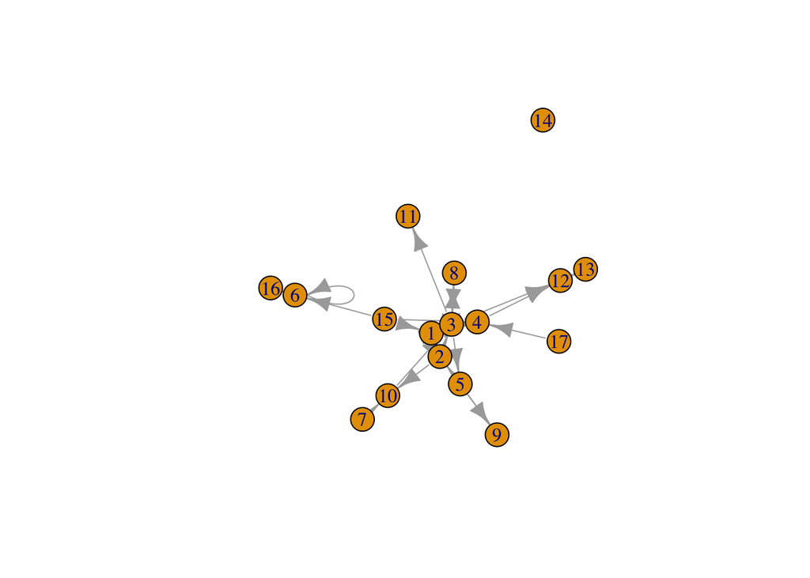

```r
plot(media_hyper)
```

```r
media_mention <- news_media %>% activate(edges) %>% filter(type=="mention")
media_mention
```

```
## # A tbl_graph: 17 nodes and 20 edges
## #
## # A directed simple graph with 3 components
## #
## # Edge Data: 20 × 4 (active)
##    from    to type    weight
##   <int> <int> <chr>    <int>
## 1     1    15 mention     20
## 2     3    10 mention      2
## 3     4     6 mention      1
## 4     4    11 mention     22
## 5     4    17 mention      2
## 6     5     1 mention      1
## # … with 14 more rows
## #
## # Node Data: 17 × 5
##   id    media               media.type type.label audience.size
##   <chr> <chr>                    <int> <chr>              <int>
## 1 s01   NY Times                     1 Newspaper             20
## 2 s02   Washington Post              1 Newspaper             25
## 3 s03   Wall Street Journal          1 Newspaper             30
## # … with 14 more rows
```

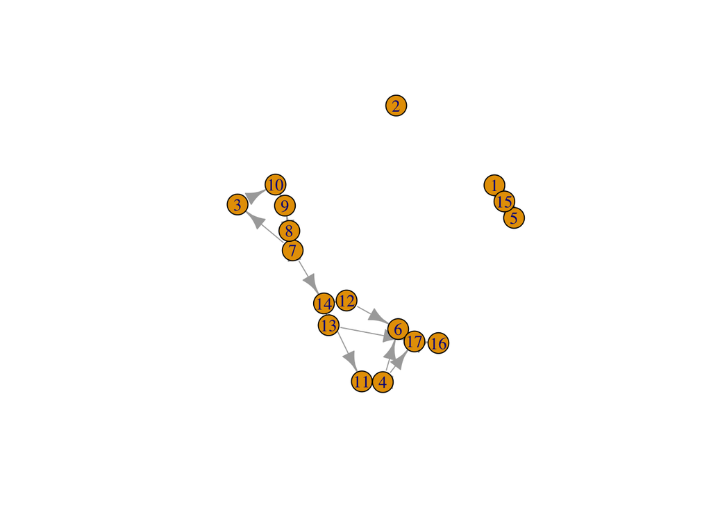

```r
plot(media_mention)
```

**EXAMPLE 2.** Now, please again try to join newly created two data sets. HINT:You can do an operation similar to full join by using the **graph_join()** function.

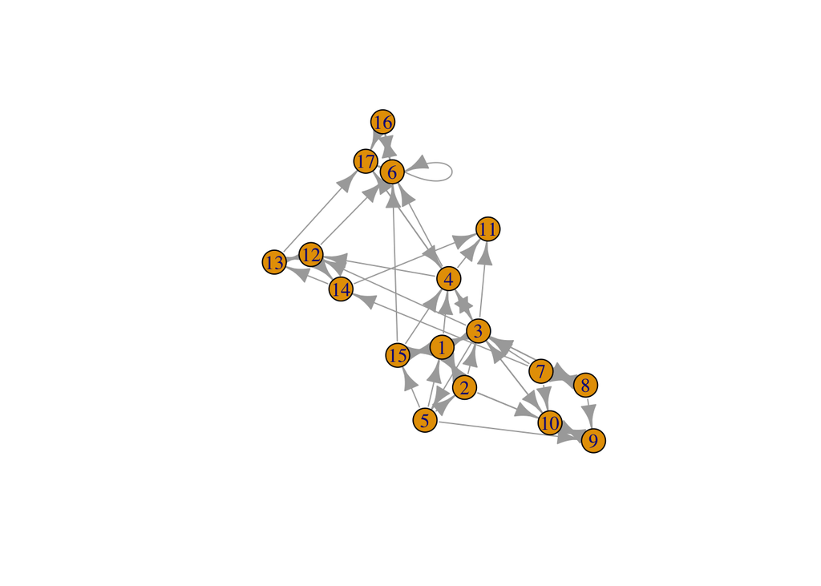

```r
media_mention %>% graph_join(media_hyper) %>% plot()
```

**EXAMPLE 3.** You are doing great! In the next step, let’s change the order of our network. HINT: Try using **reroute()**. It takes usually two arguments, from =… and to=…

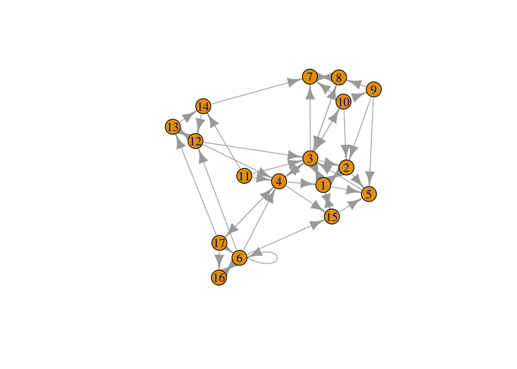

```r
media_reversed<-news_media %>% activate(edges)%>%reroute(from = to, to = from)
plot(media_reversed)
```

## GGRAPH - EXERCISES

**EXAMPLE 1** Create a ggraph. Use the “news_media” data, color edges in gray, add labels and represent nodes as points

```
## Using `stress` as default layout
```

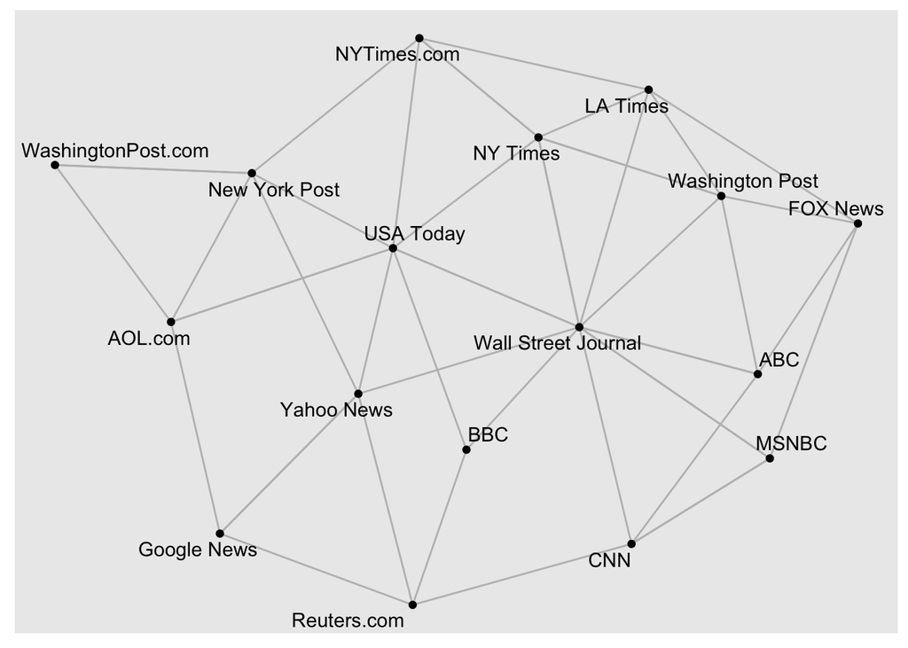

```r
ggraph(news_media) +
  geom_edge_link(color="gray") + geom_node_text(aes(label = media), repel=TRUE) + geom_node_point()
```

**EXAMPLE 2** Create a new ggraph. Use the “news_media” data, change the color depending on type of links (edges), add labels.

```
## Using `stress` as default layout
```

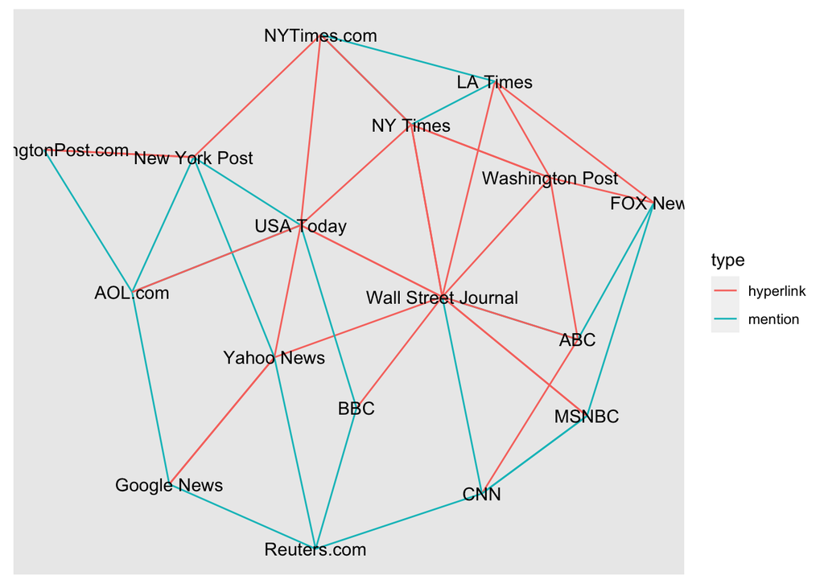

```r
ggraph(news_media) +
geom_edge_link(aes(color = type)) +
 geom_node_text(aes(label = media))
```

**EXAMPLE 3** Do you find this graph informative? If not, why? How would you improve it?

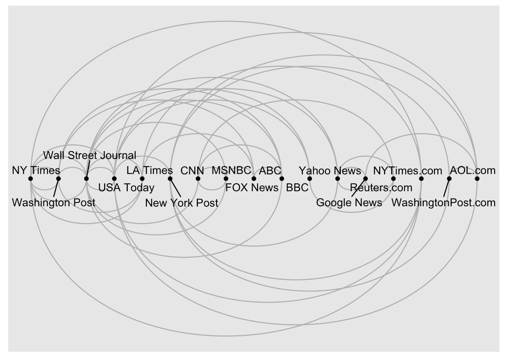

```r
ggraph(news_media, layout='linear') +
  geom_edge_arc(color="gray") + geom_node_text(aes(label = media), repel=TRUE)+ geom_node_point()
```

**CHALLENGE 1** Create a graph that includes also the weight of the edges and contains labels of the nodes.

```
## Using `stress` as default layout
```

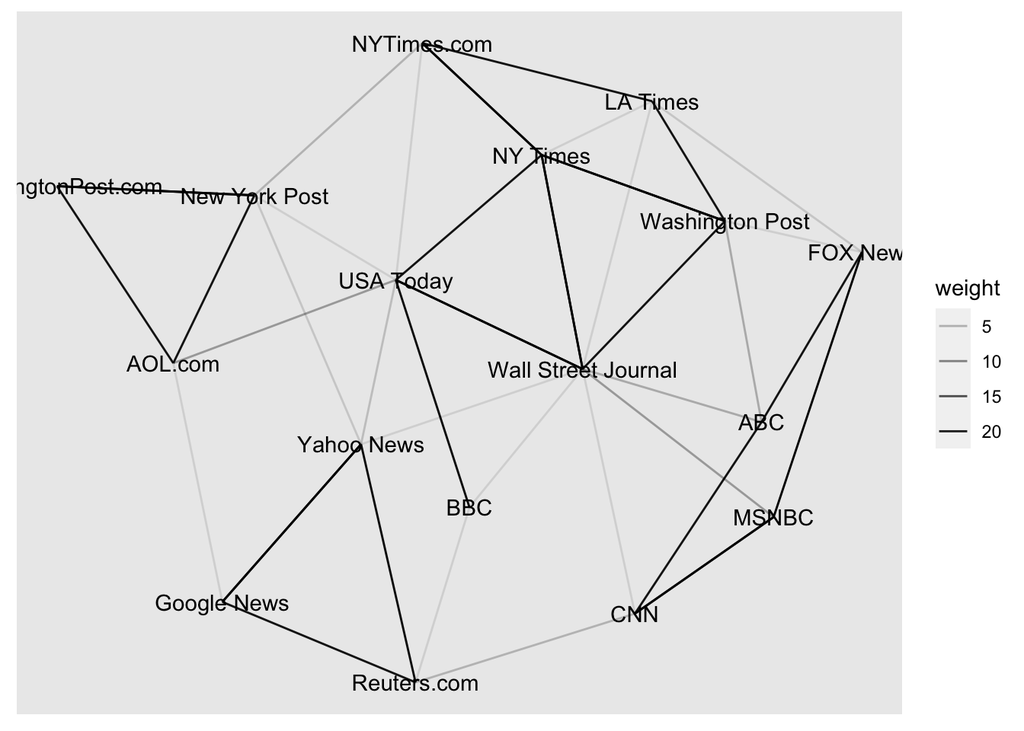

```r
ggraph(news_media) +
  geom_edge_link(aes(alpha = weight)) +
 geom_node_text(aes(label = media))
```

**CHALLENGE 2** As you already know, to measure the importance of the nodes in a particular network one can use centrality functions. Try to find out, which media is central. You can do it in many ways, but try to measure centrality by using the number of edges a node has.

HINT: We introduced you to **centrality_degree()** and **centrality_betweenness()**. Plot the centrality using ggraph().

```r
news_media%>%  activate(nodes) %>%
  mutate(centrality = centrality_degree()) %>% arrange(centrality)
```

```
## # A tbl_graph: 17 nodes and 49 edges
## #
## # A directed multigraph with 1 component
## #
## # Node Data: 17 × 6 (active)
##   id    media       media.type type.label audience.size centrality
##   <chr> <chr>            <int> <chr>              <int>      <dbl>
## 1 s11   BBC                  2 TV                    34          0
## 2 s09   FOX News             2 TV                    60          1
## 3 s10   ABC                  2 TV                    23          1
## 4 s17   AOL.com              3 Online                33          1
## 5 s13   Google News          3 Online                23          2
## 6 s14   Reuters.com          3 Online                12          2
## # … with 11 more rows
## #
## # Edge Data: 49 × 4
##    from    to type      weight
##   <int> <int> <chr>      <int>
## 1    12    13 hyperlink     22
## 2    12    17 hyperlink     22
## 3    12    16 hyperlink     21
## # … with 46 more rows
```

```
## Using `stress` as default layout
```

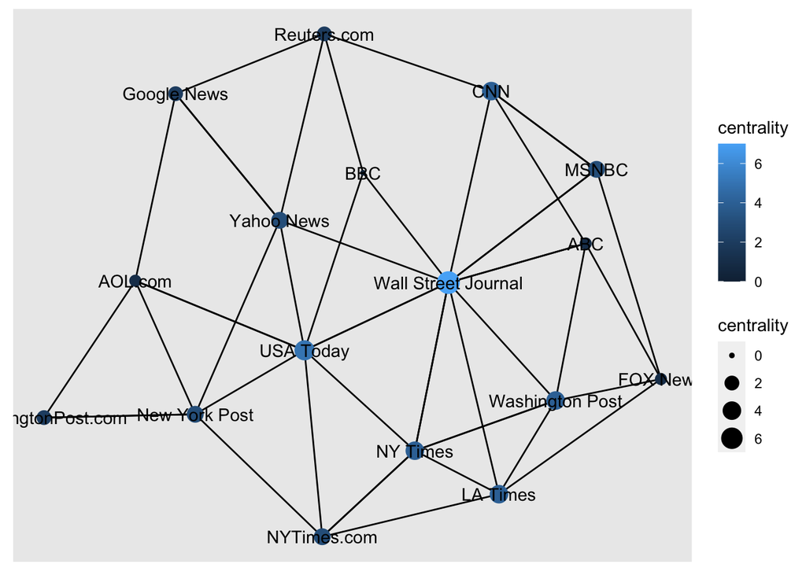

```r
news_media%>%  activate(nodes) %>%
  mutate(centrality = centrality_degree())%>% arrange(centrality)%>%
    ggraph() +
    geom_edge_link() +
    geom_node_point(aes(size = centrality, colour = centrality))+ geom_node_text(aes(label = media))
```

**FOR FURTHER INTEREST** You can describe what type of network your data represent, how many elements it has and add new values to it. HINT: There are functions that allow you to check this information. E.g., have a look at **is_directed()**. More on structures you can find here: https://michaelgastner.com/DAVisR2021/essentials-of-network-analysis.html#sec:centrality